# Temperature data

Villaseñor-Derbez J.C.

Last compiled on 2023-07-05

```r
knitr::opts_chunk$set(echo = TRUE,
                      warning = FALSE,
                      message = FALSE)
```

# 1 Load packages

```r
suppressPackageStartupMessages({
  # library(startR) #custom functions
  library(lubridate) #handle dates
  library(here) #path management
  library(rnaturalearth) #coastlines and basemaps
  library(raster) #work with the NC file
  library(tidyverse) #data management
})
```

# 2 The data

These data are already on a 0.5 degree resolution, so there’s no downscaling needed. We will just crop the extent, rotate the rasters, mask by chile, and create a panel.

## 2.1 Load the data

```r
temp <- brick(here("raw_data", "air_temp.nc"))
```

## 2.2 Preview the data

Let’s take a look at the first 12 months of data on each raster. The title in each plot contains the date.

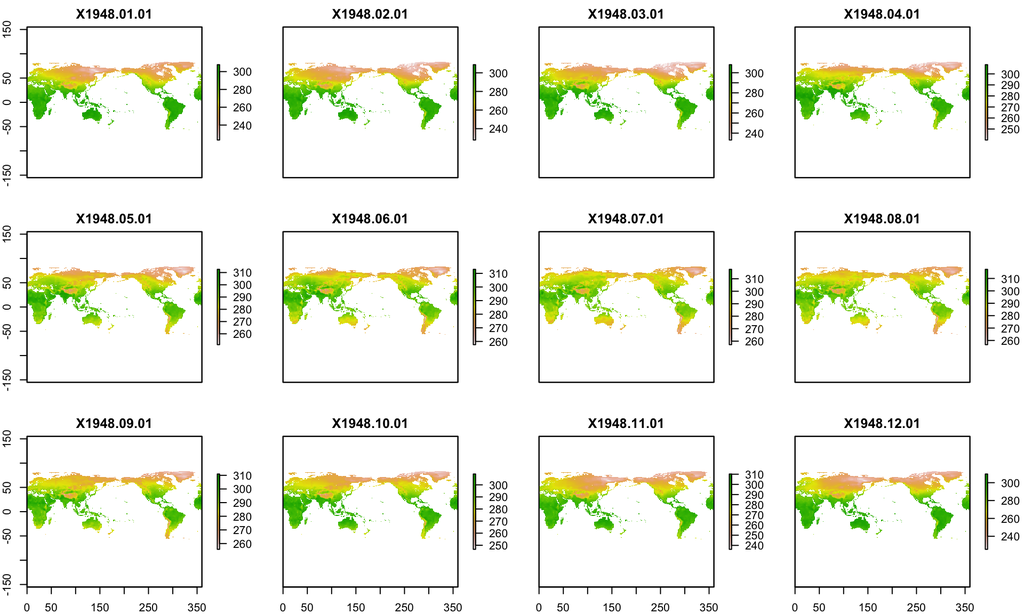

Figure 2.1: First 12 months of data in the high resolution raster

```r
plot(temp[[1:12]])
```

# 3 Modifications

The figure above show global temperature over land. But we are only interested in Chile. In order to better manage the data, we must crop these rasters to the extent (boundign box) of Chile. Let’s get a shapefile for Chile.

## 3.1 Chilean boundary

The `rnaturalearth` package contains a repository of different political boundaries of interest. We can retrieve Chile’s shapefile with the following lines.

```r
# Load chile boundaries
chl <- ne_countries(scale = "large", country = "Chile", returnclass = "sp")
```

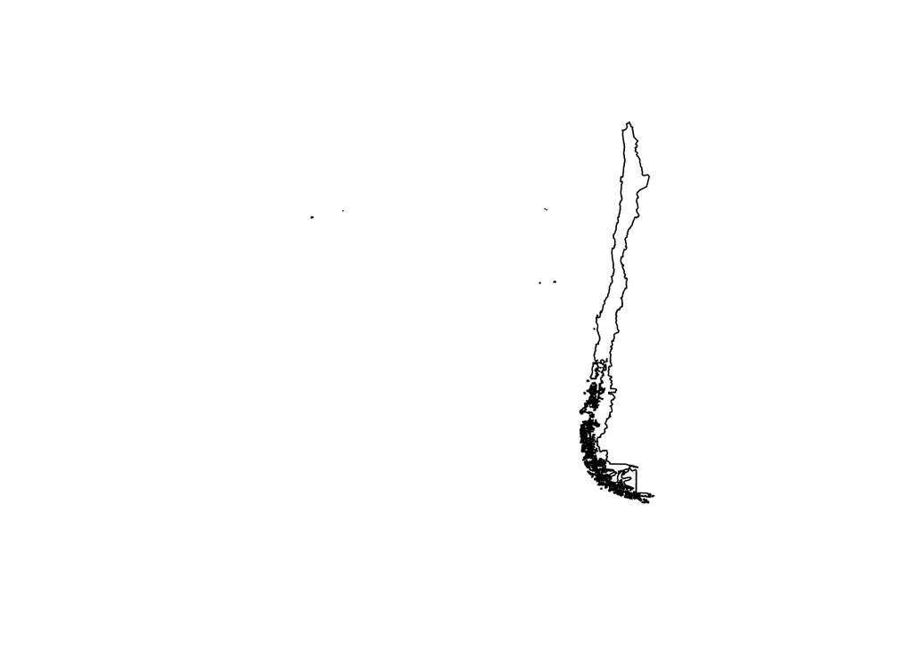

Figure 3.1: Chilean boundarie from rnaturalearth

```r
plot(chl)
```

## 3.2 Modify extent

Figures 2.1 shows how the data are global and that longitude goes from 0 to 360. Let’s fix that first by cropping down to the extent of Chile, rotating the rasters, and then masking it by Chile.

```r
# Get Chile's extent and "rotate" its longitude
chl_extent <- extent(chl) + c(360, 360, 0, 0)

# Reduce size to extent of chile
temp_ext <- crop(temp, y = chl_extent)
```

The rasters are now cropped to Chile’s extent.

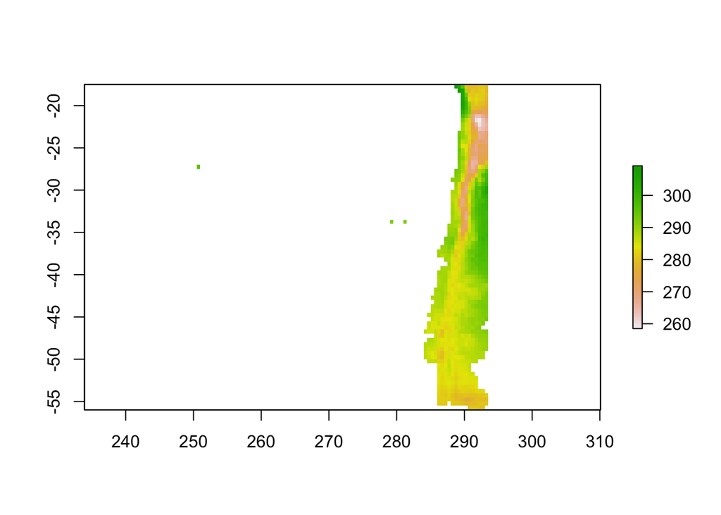

Figure 3.2: First month of temperature for Chile

```r
plot(temp_ext[[1]])
```

## 3.3 Convert units

Note that the colorbar indicates temperatures from 260 to 300. This is because it is in Kelvin. Let’s convert the data to celsius.

```r
# Convert units
temp_cel <- temp_ext -273.15
```

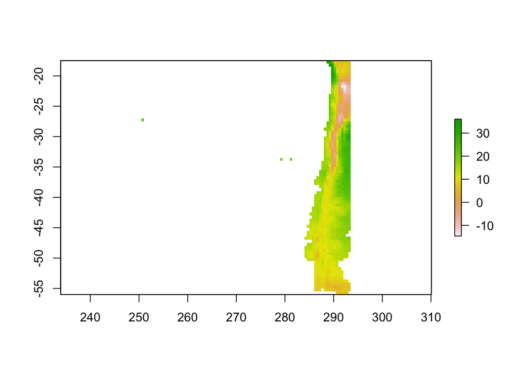

Figure 3.3: FData converted to celsius

```r
plot(temp_cel[[1]])
```

## 3.4 Rotate to -180 to 180

```r
# Rotate the raster
temp_rot <- rotate(temp_cel)
```

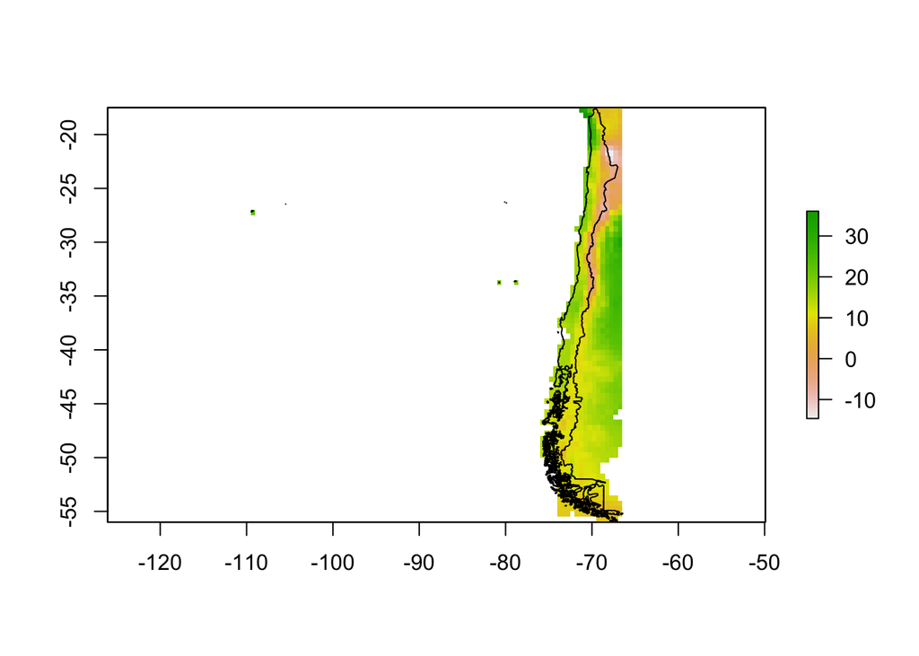

```r
plot(temp_rot[[1]])
plot(chl, add = T)
```

## 3.5 Crop to Chile

The above figures show all data in the extent, but we want them for cells that are within Chile only. We first reduce the extent because it’s an operation that collects cells within 4 points (the bounding box). Now that we have less data, we can use a more intricate shape to extract the data. In this case, Chile’s boundary.

```r
temp_chl <- mask(temp_rot, chl)
```

```r
writeRaster(x = temp_chl,
            filename = here("data", "temperature_raster_chile.tif"),
            overwrite = T)
```

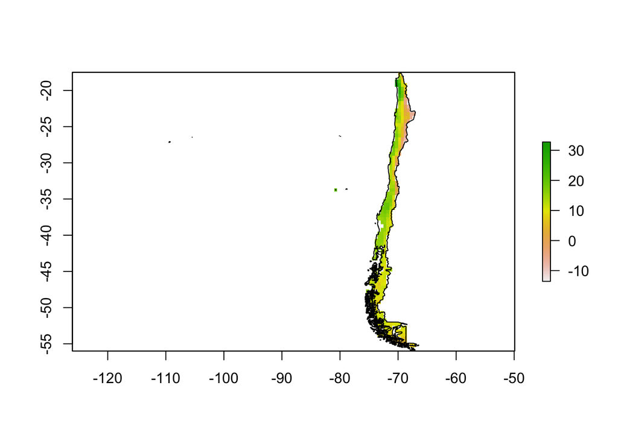

```r
plot(temp_chl[[1]])
plot(chl, add = T)
```

# 4 Finalize the data

## 4.1 Convert to a `data.frame`

```r
temp_df <- raster::as.data.frame(temp_chl, xy = T) %>%
  gather(date, temp, -c(x, y)) %>%
  drop_na() %>%
  mutate(date = str_remove(date, "X")) %>%
  separate(date, sep = "\\.", into = c("year", "month", "day", "hour", "minute", "second")) %>%
  mutate(date = date(paste(year, month, day, sep = "-"))) %>%
  select(lon = x, lat = y, year, month, day, date, temp)
```

```r
head(temp_df)
```

```
##      lon    lat year month day       date      temp
## 1 -69.75 -17.75 1948    01  01 1948-01-01  7.740015
## 2 -69.75 -18.25 1948    01  01 1948-01-01 14.980005
## 3 -69.25 -18.25 1948    01  01 1948-01-01  5.209985
## 4 -70.25 -18.75 1948    01  01 1948-01-01 32.050011
## 5 -69.75 -18.75 1948    01  01 1948-01-01 20.809992
## 6 -69.25 -18.75 1948    01  01 1948-01-01  8.279993
```

## 4.2 Export the resulting data

```r
write.csv(x = temp_df,
          file = here("data", "temperature_panel.csv"),
          row.names = F)
```

## 4.3 Further inspection

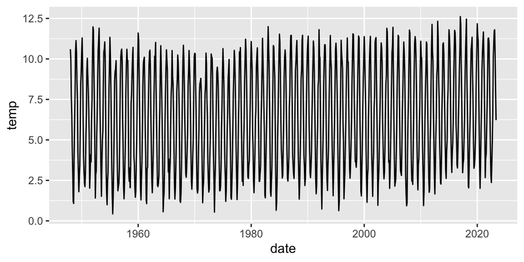

Figure 4.1: Time series of surface temperature in chile.

```r
temp_df %>%
  group_by(date) %>%
  summarize(temp = mean(temp, na.rm = T)) %>%
  ungroup() %>%
  ggplot(aes(x = date, y = temp)) +
  geom_line()
```

## 5.2 System info

```r
Sys.info()
```

```
##                                                                                            sysname
##                                                                                           "Darwin"
##                                                                                            release
##                                                                                           "22.5.0"
##                                                                                            version
## "Darwin Kernel Version 22.5.0: Thu Jun  8 22:22:22 PDT 2023; root:xnu-8796.121.3~7/RELEASE_X86_64"
##                                                                                           nodename
##                                                                    "HMS-C02CH1S8MD6T.stanford.edu"
##                                                                                            machine
##                                                                                           "x86_64"
##                                                                                              login
##                                                                                             "root"
##                                                                                               user
##                                                                       "juancarlosvillasenorderbez"
##                                                                                     effective_user
##                                                                       "juancarlosvillasenorderbez"
```